# Authentic and Full Inclusion

Janette Avelar

2023-05-19

# What are the biggest tagging differences among schools with inclusive classrooms?

# Which tags were schools designing to meet the needs of students who have been marginalized most likely to select?

### Most selected tags

```r
marginalized <- full %>%
  select(starts_with("practices_")) %>%
  filter(practices_design_marginalized == 1) %>%
  select(-practices_design_marginalized) %>%
  pivot_longer(cols = starts_with("practices_"),
               names_to = "Tag",
               values_to = "N") %>%
  group_by(Tag) %>%
  summarize(N = sum(N)) %>%
  arrange(desc(N)) %>%
  head(n = 10)
#table
datatable(marginalized)
```

|  | Tag | N |
| --- | --- | --- |
| 1 | practices_culturally_responsive | 160 |
| 2 | practices_pbl | 160 |
| 3 | practices_all_courses_designed_for_inclusion | 157 |
| 4 | practices_opportunities_mastery | 156 |
| 5 | practices_restorative | 154 |
| 6 | practices_sel_integrated | 151 |
| 7 | practices_community_partnerships | 145 |
| 8 | practices_mental_health | 142 |
| 9 | practices_performance_assessment | 142 |
| 10 | practices_accommodations | 139 |

### Most and least likely

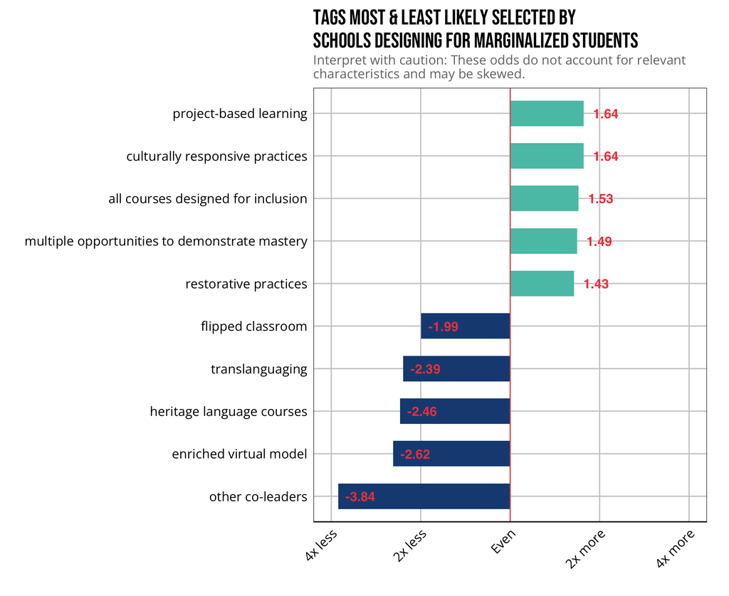

```r
marginalized_odd <- tags %>%
  select(starts_with("practices_")) %>%
  filter(practices_design_marginalized == 1) %>%
  select(-practices_design_marginalized) %>%
  pivot_longer(cols = starts_with("practices_"),
               names_to = "tag",
               values_to = "n") %>%
  group_by(tag) %>%
  summarize(n = sum(n)) %>%
  mutate(prob = n/191,
         odds = prob/(1-prob),
         lor = log(odds)) %>%
  arrange(desc(n)) %>%
  ungroup() %>%
  filter(n > 153 |
           n < 24) %>%
  mutate(likely = case_when(
    n > 153 ~ "more",
    n < 24 ~ "less"
  ))
#plot
ggplot(marginalized_odd, aes(reorder(tag, lor), lor, fill = likely)) +
  geom_col() +
  scale_x_discrete(labels = label_tags()) +
  scale_fill_manual(values = transcend_cols[1:2]) +
  labs(title = "Tags Most & Least Likely Selected by\nSchools Designing for Marginalized Students",
       subtitle = "Interpret with caution: These odds do not account for relevant\ncharacteristics and may be skewed.",
       x = "",
       y = "") +
  coord_flip() +
  theme(legend.position = "none",
        axis.text.x = element_text(angle = 45, hjust = 1)) +
  scale_y_continuous(limits=c(-4, 4),
                     labels = c("-4" = "4x less",
                            "-2" = "2x less",
                            "0" = "Even",
                            "2" = "2x more",
                            "4" = "4x more")) +
  geom_hline(yintercept = 0, color = transcend_cols[3]) +
  geom_text(aes(label = signif(round(lor, 2))),
            nudge_y = .5,
            color = transcend_cols[3],
            fontface = "bold",
            size = 5,
            family = "sans")
```

# Which tags were schools with inclusive classrooms most likely to select?

### Most selected tags

```r
inclusive <- full %>%
  select(starts_with("practices_")) %>%
  filter(practices_all_courses_designed_for_inclusion == 1) %>%
  select(-practices_all_courses_designed_for_inclusion) %>%
  pivot_longer(cols = starts_with("practices_"),
               names_to = "Tag",
               values_to = "N") %>%
  group_by(Tag) %>%
  summarize(N = sum(N)) %>%
  arrange(desc(N)) %>%
  head(n = 10)
#table
datatable(inclusive)
```

|  | Tag | N |
| --- | --- | --- |
| 1 | practices_design_marginalized | 157 |
| 2 | practices_pbl | 157 |
| 3 | practices_opportunities_mastery | 154 |
| 4 | practices_culturally_responsive | 150 |
| 5 | practices_restorative | 145 |
| 6 | practices_community_partnerships | 143 |
| 7 | practices_sel_integrated | 142 |
| 8 | practices_performance_assessment | 137 |
| 9 | practices_assessments_deeper | 135 |
| 10 | practices_interdisciplinary | 135 |

### Most and least likely

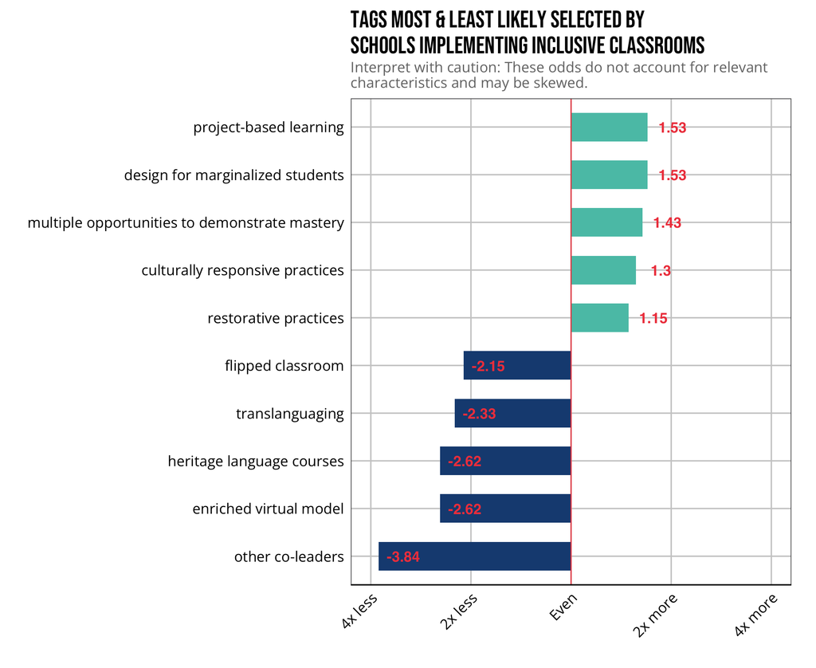

```r
inclusive_odd <- tags %>%
  select(starts_with("practices_")) %>%
  filter(practices_all_courses_designed_for_inclusion == 1) %>%
  select(-practices_all_courses_designed_for_inclusion) %>%
  pivot_longer(cols = starts_with("practices_"),
               names_to = "tag",
               values_to = "n") %>%
  group_by(tag) %>%
  summarize(n = sum(n)) %>%
  mutate(prob = n/191,
         odds = prob/(1-prob),
         lor = log(odds)) %>%
  arrange(desc(n)) %>%
  ungroup() %>%
  filter(n > 144 |
           n < 21) %>%
  mutate(likely = case_when(
    n > 144 ~ "more",
    n < 21 ~ "less"
  ))
#plot
ggplot(inclusive_odd, aes(reorder(tag, lor), lor, fill = likely)) +
  geom_col() +
  scale_x_discrete(labels = label_tags()) +
  scale_fill_manual(values = transcend_cols[1:2]) +
  labs(title = "Tags Most & Least Likely Selected by\nSchools Implementing Inclusive Classrooms",
       subtitle = "Interpret with caution: These odds do not account for relevant\ncharacteristics and may be skewed.",
       x = "",
       y = "") +
  coord_flip() +
  theme(legend.position = "none",
        axis.text.x = element_text(angle = 45, hjust = 1)) +
  scale_y_continuous(limits=c(-4, 4),
                     labels = c("-4" = "4x less",
                            "-2" = "2x less",
                            "0" = "Even",
                            "2" = "2x more",
                            "4" = "4x more")) +
  geom_hline(yintercept = 0, color = transcend_cols[3]) +
  geom_text(aes(label = signif(round(lor, 2))),
            nudge_y = .5,
            color = transcend_cols[3],
            fontface = "bold",
            size = 5,
            family = "sans")
```

# Which leaps were schools designing to meet the needs of students who have been marginalized more likely to select?

### Most selected leaps

The percentage column below indicates the proportion of schools selecting `design to meet the needs of students who have been marginalized` that also selected each given Leap.

A possible next step here is to disaggregate by the specific student group(s) schools were designing for, but this is not a priority task.

```r
leaps <- full %>%
  select(starts_with("leaps"), practices_design_marginalized) %>%
  select(-starts_with("leaps_rank"), -leaps_interest) %>%
  filter(practices_design_marginalized == 1) %>%
  select(-practices_design_marginalized) %>%
  pivot_longer(cols = starts_with("leaps"),
               names_to = "Leap",
               values_to = "N") %>%
  group_by(Leap) %>%
  summarize(N = sum(N, na.rm = TRUE),
            Pct = paste0(round(N/191, 2)*100, "%")) %>%
  arrange(desc(N))
#table
datatable(leaps)
```

|  | Leap | N | Pct |
| --- | --- | --- | --- |
| 1 | leaps_high_expectations | 145 | 76% |
| 2 | leaps_connection | 144 | 75% |
| 3 | leaps_whole_child | 135 | 71% |
| 4 | leaps_customization | 126 | 66% |
| 5 | leaps_relevance | 126 | 66% |
| 6 | leaps_rigorous_learning | 123 | 64% |
| 7 | leaps_affirmation | 117 | 61% |
| 8 | leaps_self_direction | 114 | 60% |
| 9 | leaps_social_consciousness | 103 | 54% |
| 10 | leaps_anytime_anywhere | 84 | 44% |

### Most and least likely

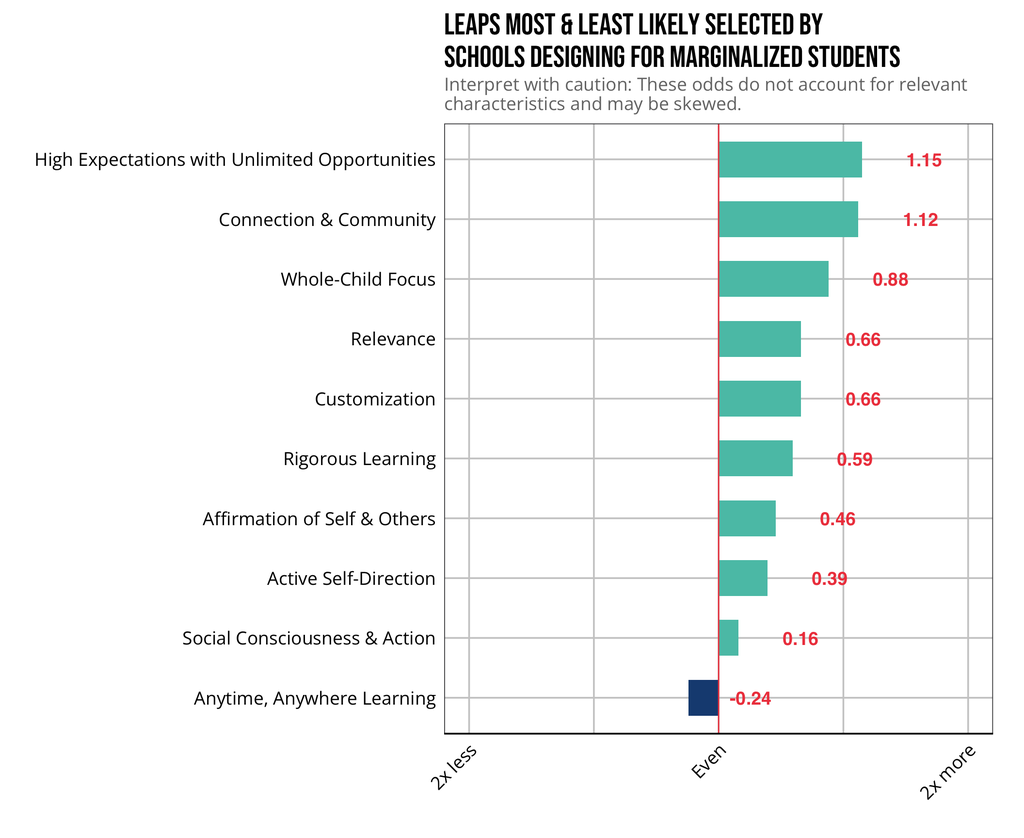

```r
leaps_odd <- full %>%
  select(starts_with("leaps"), practices_design_marginalized) %>%
  select(-starts_with("leaps_rank"), -leaps_interest) %>%
  filter(practices_design_marginalized == 1) %>%
  select(-practices_design_marginalized) %>%
  pivot_longer(cols = starts_with("leaps"),
               names_to = "leap",
               values_to = "n") %>%
  group_by(leap) %>%
  summarize(n = sum(n, na.rm = TRUE)) %>%
  mutate(prob = n/191,
         odds = prob/(1-prob),
         lor = log(odds)) %>%
  arrange(desc(n)) %>%
  mutate(likely = case_when(
    lor > 0 ~ "more",
    lor < 0 ~ "less"
  ))
#create labels for plot

#plot
ggplot(leaps_odd, aes(reorder(leap, lor), lor, fill = likely)) +
  geom_col() +
  scale_x_discrete(labels = label_leaps) +
  scale_fill_manual(values = transcend_cols[1:2]) +
  labs(title = "Leaps Most & Least Likely Selected by\nSchools Designing for Marginalized Students",
       subtitle = "Interpret with caution: These odds do not account for relevant\ncharacteristics and may be skewed.",
       x = "",
       y = "") +
  coord_flip() +
  theme(legend.position = "none",
        axis.text.x = element_text(angle = 45, hjust = 1)) +
  scale_y_continuous(limits=c(-2, 2),
                     labels = c("-2" = "2x less",
                                "-1" = "",
                            "0" = "Even",
                            "1" = "",
                            "2" = "2x more")) +
  geom_hline(yintercept = 0, color = transcend_cols[3]) +
  geom_text(aes(label = signif(round(lor, 2))),
            nudge_y = .5,
            color = transcend_cols[3],
            fontface = "bold",
            size = 5,
            family = "sans")
```